# Project: Investigate No-Show Appointments Dataset

- Introduction
- Data Wrangling
- Exploratory Data Analysis
- Conclusions

## Introduction

> This dataset collects information from 100k medical appointments in Brazil and is focused on the question of whether or not patients show up for their appointment. A number of characteristics about the patient are included in each row.

> ‘ScheduledDay’ tells us on what day the patient set up their appointment. ‘Neighborhood’ indicates the location of the hospital. ‘Scholarship’ indicates whether or not the patient is enrolled in Brasilian welfare program Bolsa Família. Be careful about the encoding of the last column: it says ‘No’ if the patient showed up to their appointment, and ‘Yes’  
> if they did not show up.

```python
#Loading necessary Packages
import numpy as np
import pandas as pd
import matplotlib.pyplot as plt
import seaborn as sns

#This lets to view your plots in the notebook
% matplotlib inline
```

## Data Wrangling

This involves the following steps

Step 1 - Gathering Data

Step 2 - Assess the Data - This involves identifying any problems in your data quality or structure .

Step 3 - Cleaning the Data - Involves modifying , replacing or moving data to ensure that your data set is as high quality and well structured as well.

### General Properties

```python
# Load your data and print out a few lines. Perform operations to inspect data
#   types and look for instances of missing or possibly errant data.
no_show = pd.read_csv('KaggleV2-NoshowAppointment.csv')
# To inspect lets Look at the first 10 rows of data
no_show.head(10)
```

|  | PatientId | AppointmentID | Gender | ScheduledDay | AppointmentDay | Age | Neighbourhood | Scholarship | Hipertension | Diabetes | Alcoholism | Handcap | SMS_received | No-show |
| --- | --- | --- | --- | --- | --- | --- | --- | --- | --- | --- | --- | --- | --- | --- |
| 0 | 2.987250e+13 | 5642903 | F | 2016-04-29T18:38:08Z | 2016-04-29T00:00:00Z | 62 | JARDIM DA PENHA | 0 | 1 | 0 | 0 | 0 | 0 | No |
| 1 | 5.589978e+14 | 5642503 | M | 2016-04-29T16:08:27Z | 2016-04-29T00:00:00Z | 56 | JARDIM DA PENHA | 0 | 0 | 0 | 0 | 0 | 0 | No |
| 2 | 4.262962e+12 | 5642549 | F | 2016-04-29T16:19:04Z | 2016-04-29T00:00:00Z | 62 | MATA DA PRAIA | 0 | 0 | 0 | 0 | 0 | 0 | No |
| 3 | 8.679512e+11 | 5642828 | F | 2016-04-29T17:29:31Z | 2016-04-29T00:00:00Z | 8 | PONTAL DE CAMBURI | 0 | 0 | 0 | 0 | 0 | 0 | No |
| 4 | 8.841186e+12 | 5642494 | F | 2016-04-29T16:07:23Z | 2016-04-29T00:00:00Z | 56 | JARDIM DA PENHA | 0 | 1 | 1 | 0 | 0 | 0 | No |
| 5 | 9.598513e+13 | 5626772 | F | 2016-04-27T08:36:51Z | 2016-04-29T00:00:00Z | 76 | REPÚBLICA | 0 | 1 | 0 | 0 | 0 | 0 | No |
| 6 | 7.336882e+14 | 5630279 | F | 2016-04-27T15:05:12Z | 2016-04-29T00:00:00Z | 23 | GOIABEIRAS | 0 | 0 | 0 | 0 | 0 | 0 | Yes |
| 7 | 3.449833e+12 | 5630575 | F | 2016-04-27T15:39:58Z | 2016-04-29T00:00:00Z | 39 | GOIABEIRAS | 0 | 0 | 0 | 0 | 0 | 0 | Yes |
| 8 | 5.639473e+13 | 5638447 | F | 2016-04-29T08:02:16Z | 2016-04-29T00:00:00Z | 21 | ANDORINHAS | 0 | 0 | 0 | 0 | 0 | 0 | No |
| 9 | 7.812456e+13 | 5629123 | F | 2016-04-27T12:48:25Z | 2016-04-29T00:00:00Z | 19 | CONQUISTA | 0 | 0 | 0 | 0 | 0 | 0 | No |

Let's know the Dimensions of the dataset that is being investigated

```python
no_show.shape
```

```
(110527, 14)
```

Let's now know the datatypes of the columns

```python
no_show.columns
```

```
Index(['PatientId', 'AppointmentID', 'Gender', 'ScheduledDay',
       'AppointmentDay', 'Age', 'Neighbourhood', 'Scholarship', 'Hipertension',
       'Diabetes', 'Alcoholism', 'Handcap', 'SMS_received', 'No-show'],
      dtype='object')
```

We see that column names do not follow the conventional naming rules . So renaming columns should be done .

```python
no_show.dtypes
```

```
PatientId         float64
AppointmentID       int64
Gender             object
ScheduledDay       object
AppointmentDay     object
Age                 int64
Neighbourhood      object
Scholarship         int64
Hipertension        int64
Diabetes            int64
Alcoholism          int64
Handcap             int64
SMS_received        int64
No-show            object
dtype: object
```

Now we see that ScheduledDay and AppointmentDay have datatype "object" , lets further investigate these two columns

```python
type(no_show['ScheduledDay'][0])
```

```
str
```

```python
type(no_show['AppointmentDay'][0])
```

```
str
```

Further Investigation shows that the datatype of the ScheduledDay and AppointmentDay columns are of String Type . So during Data Cleaning we should make sure we convert it into appropriate datatype i.e , date

```python
#Concise summary of the dataset
no_show.info()
```

```
<class 'pandas.core.frame.DataFrame'>
RangeIndex: 110527 entries, 0 to 110526
Data columns (total 14 columns):
PatientId         110527 non-null float64
AppointmentID     110527 non-null int64
Gender            110527 non-null object
ScheduledDay      110527 non-null object
AppointmentDay    110527 non-null object
Age               110527 non-null int64
Neighbourhood     110527 non-null object
Scholarship       110527 non-null int64
Hipertension      110527 non-null int64
Diabetes          110527 non-null int64
Alcoholism        110527 non-null int64
Handcap           110527 non-null int64
SMS_received      110527 non-null int64
No-show           110527 non-null object
dtypes: float64(1), int64(8), object(5)
memory usage: 11.8+ MB
```

From the above we can see that there are no null values in any of the columns , So we need not to worry about removal of null data

```python
sum(no_show.duplicated())
```

```
0
```

No duplicate rows are present in the dataset .

```python
#Time for descriptive statistics for each column
no_show.describe()
```

|  | PatientId | AppointmentID | Age | Scholarship | Hipertension | Diabetes | Alcoholism | Handcap | SMS_received |
| --- | --- | --- | --- | --- | --- | --- | --- | --- | --- |
| count | 1.105270e+05 | 1.105270e+05 | 110527.000000 | 110527.000000 | 110527.000000 | 110527.000000 | 110527.000000 | 110527.000000 | 110527.000000 |
| mean | 1.474963e+14 | 5.675305e+06 | 37.088874 | 0.098266 | 0.197246 | 0.071865 | 0.030400 | 0.022248 | 0.321026 |
| std | 2.560949e+14 | 7.129575e+04 | 23.110205 | 0.297675 | 0.397921 | 0.258265 | 0.171686 | 0.161543 | 0.466873 |
| min | 3.921784e+04 | 5.030230e+06 | -1.000000 | 0.000000 | 0.000000 | 0.000000 | 0.000000 | 0.000000 | 0.000000 |
| 25% | 4.172614e+12 | 5.640286e+06 | 18.000000 | 0.000000 | 0.000000 | 0.000000 | 0.000000 | 0.000000 | 0.000000 |
| 50% | 3.173184e+13 | 5.680573e+06 | 37.000000 | 0.000000 | 0.000000 | 0.000000 | 0.000000 | 0.000000 | 0.000000 |
| 75% | 9.439172e+13 | 5.725524e+06 | 55.000000 | 0.000000 | 0.000000 | 0.000000 | 0.000000 | 0.000000 | 1.000000 |
| max | 9.999816e+14 | 5.790484e+06 | 115.000000 | 1.000000 | 1.000000 | 1.000000 | 1.000000 | 4.000000 | 1.000000 |

From the above , we can come to know that minimum age value is -1 and maximum is 115 and the mean age is 37.09 . From this we can say that the minimum and maximum age values can be considered as outliers and respective row data should be removed from the dataset for making sure of consistent data .

Now let's have a look at the unique values in the respective columns

```python
#Number of unique values column wise
no_show.nunique()
```

```
PatientId          62299
AppointmentID     110527
Gender                 2
ScheduledDay      103549
AppointmentDay        27
Age                  104
Neighbourhood         81
Scholarship            2
Hipertension           2
Diabetes               2
Alcoholism             2
Handcap                5
SMS_received           2
No-show                2
dtype: int64
```

Here we see that AppointmentID column have distinct/unique values in each row .

```python
no_show['Gender'].unique()
```

```
array(['F', 'M'], dtype=object)
```

```python
no_show['Scholarship'].unique()
```

```
array([0, 1])
```

```python
no_show['Age'].unique()
```

```
array([ 62,  56,   8,  76,  23,  39,  21,  19,  30,  29,  22,  28,  54,
        15,  50,  40,  46,   4,  13,  65,  45,  51,  32,  12,  61,  38,
        79,  18,  63,  64,  85,  59,  55,  71,  49,  78,  31,  58,  27,
         6,   2,  11,   7,   0,   3,   1,  69,  68,  60,  67,  36,  10,
        35,  20,  26,  34,  33,  16,  42,   5,  47,  17,  41,  44,  37,
        24,  66,  77,  81,  70,  53,  75,  73,  52,  74,  43,  89,  57,
        14,   9,  48,  83,  72,  25,  80,  87,  88,  84,  82,  90,  94,
        86,  91,  98,  92,  96,  93,  95,  97, 102, 115, 100,  99,  -1])
```

The row with age -1 is has incorrect age value , So corresponding row should be removed . People having age more than 100 can be removed from the data as it a outlier.

```python
no_show['Hipertension'].unique()
```

```
array([1, 0])
```

```python
no_show['Alcoholism'].unique()
```

```
array([0, 1])
```

```python
no_show['Handcap'].unique()
```

```
array([0, 1, 2, 3, 4])
```

```python
no_show['SMS_received'].unique()
```

```
array([0, 1])
```

```python
no_show['No-show'].unique()
```

```
array(['No', 'Yes'], dtype=object)
```

Now we have discussed the structure of the data and problems that need to be assessed, lets perform the cleaning steps

### Step 1 - Renaming Columns

```python
no_show.columns
```

```
Index(['PatientId', 'AppointmentID', 'Gender', 'ScheduledDay',
       'AppointmentDay', 'Age', 'Neighbourhood', 'Scholarship', 'Hipertension',
       'Diabetes', 'Alcoholism', 'Handcap', 'SMS_received', 'No-show'],
      dtype='object')
```

```python
no_show.columns = [x.lower() for x in no_show.columns]
no_show.columns
```

```
Index(['patientid', 'appointmentid', 'gender', 'scheduledday',
       'appointmentday', 'age', 'neighbourhood', 'scholarship', 'hipertension',
       'diabetes', 'alcoholism', 'handcap', 'sms_received', 'no-show'],
      dtype='object')
```

```python
no_show = no_show.rename(columns = {'patientid' : 'patient_id' , 'appointmentid' : 'appointment_id' , 'scheduledday':'scheduled_day' , 'appointmentday' : 'appointment_day' , 'handcap' : 'handicap' ,'no-show': 'no_show'})
```

```python
no_show.columns
```

```
Index(['patient_id', 'appointment_id', 'gender', 'scheduled_day',
       'appointment_day', 'age', 'neighbourhood', 'scholarship',
       'hipertension', 'diabetes', 'alcoholism', 'handicap', 'sms_received',
       'no_show'],
      dtype='object')
```

```python
no_show.head()
```

|  | patient_id | appointment_id | gender | scheduled_day | appointment_day | age | neighbourhood | scholarship | hipertension | diabetes | alcoholism | handicap | sms_received | no_show |
| --- | --- | --- | --- | --- | --- | --- | --- | --- | --- | --- | --- | --- | --- | --- |
| 0 | 2.987250e+13 | 5642903 | F | 2016-04-29T18:38:08Z | 2016-04-29T00:00:00Z | 62 | JARDIM DA PENHA | 0 | 1 | 0 | 0 | 0 | 0 | No |
| 1 | 5.589978e+14 | 5642503 | M | 2016-04-29T16:08:27Z | 2016-04-29T00:00:00Z | 56 | JARDIM DA PENHA | 0 | 0 | 0 | 0 | 0 | 0 | No |
| 2 | 4.262962e+12 | 5642549 | F | 2016-04-29T16:19:04Z | 2016-04-29T00:00:00Z | 62 | MATA DA PRAIA | 0 | 0 | 0 | 0 | 0 | 0 | No |
| 3 | 8.679512e+11 | 5642828 | F | 2016-04-29T17:29:31Z | 2016-04-29T00:00:00Z | 8 | PONTAL DE CAMBURI | 0 | 0 | 0 | 0 | 0 | 0 | No |
| 4 | 8.841186e+12 | 5642494 | F | 2016-04-29T16:07:23Z | 2016-04-29T00:00:00Z | 56 | JARDIM DA PENHA | 0 | 1 | 1 | 0 | 0 | 0 | No |

### Step 2 - Fixing DataTypes

```python
no_show['scheduled_day'] = pd.to_datetime(no_show['scheduled_day'])
type(no_show['scheduled_day'][0])
```

```
pandas._libs.tslib.Timestamp
```

```python
no_show['appointment_day'] = pd.to_datetime(no_show['appointment_day'])
type(no_show['appointment_day'][0])
```

```
pandas._libs.tslib.Timestamp
```

```python
no_show.head()
```

|  | patient_id | appointment_id | gender | scheduled_day | appointment_day | age | neighbourhood | scholarship | hipertension | diabetes | alcoholism | handicap | sms_received | no_show |
| --- | --- | --- | --- | --- | --- | --- | --- | --- | --- | --- | --- | --- | --- | --- |
| 0 | 2.987250e+13 | 5642903 | F | 2016-04-29 18:38:08 | 2016-04-29 | 62 | JARDIM DA PENHA | 0 | 1 | 0 | 0 | 0 | 0 | No |
| 1 | 5.589978e+14 | 5642503 | M | 2016-04-29 16:08:27 | 2016-04-29 | 56 | JARDIM DA PENHA | 0 | 0 | 0 | 0 | 0 | 0 | No |
| 2 | 4.262962e+12 | 5642549 | F | 2016-04-29 16:19:04 | 2016-04-29 | 62 | MATA DA PRAIA | 0 | 0 | 0 | 0 | 0 | 0 | No |
| 3 | 8.679512e+11 | 5642828 | F | 2016-04-29 17:29:31 | 2016-04-29 | 8 | PONTAL DE CAMBURI | 0 | 0 | 0 | 0 | 0 | 0 | No |
| 4 | 8.841186e+12 | 5642494 | F | 2016-04-29 16:07:23 | 2016-04-29 | 56 | JARDIM DA PENHA | 0 | 1 | 1 | 0 | 0 | 0 | No |

### Step 3 - Removing Outliers

```python
no_show = no_show.query('age>=0')
no_show = no_show.query('age<=100')
```

```python
no_show['age'].unique()
```

```
array([ 62,  56,   8,  76,  23,  39,  21,  19,  30,  29,  22,  28,  54,
        15,  50,  40,  46,   4,  13,  65,  45,  51,  32,  12,  61,  38,
        79,  18,  63,  64,  85,  59,  55,  71,  49,  78,  31,  58,  27,
         6,   2,  11,   7,   0,   3,   1,  69,  68,  60,  67,  36,  10,
        35,  20,  26,  34,  33,  16,  42,   5,  47,  17,  41,  44,  37,
        24,  66,  77,  81,  70,  53,  75,  73,  52,  74,  43,  89,  57,
        14,   9,  48,  83,  72,  25,  80,  87,  88,  84,  82,  90,  94,
        86,  91,  98,  92,  96,  93,  95,  97, 100,  99])
```

```python
no_show.describe()
```

|  | patient_id | appointment_id | age | scholarship | hipertension | diabetes | alcoholism | handicap | sms_received |
| --- | --- | --- | --- | --- | --- | --- | --- | --- | --- |
| count | 1.105190e+05 | 1.105190e+05 | 110519.000000 | 110519.000000 | 110519.000000 | 110519.000000 | 110519.000000 | 110519.000000 | 110519.000000 |
| mean | 1.474860e+14 | 5.675303e+06 | 37.084519 | 0.098273 | 0.197251 | 0.071870 | 0.030402 | 0.022213 | 0.321040 |
| std | 2.560826e+14 | 7.129600e+04 | 23.103165 | 0.297684 | 0.397925 | 0.258274 | 0.171692 | 0.161441 | 0.466878 |
| min | 3.921784e+04 | 5.030230e+06 | 0.000000 | 0.000000 | 0.000000 | 0.000000 | 0.000000 | 0.000000 | 0.000000 |
| 25% | 4.172457e+12 | 5.640284e+06 | 18.000000 | 0.000000 | 0.000000 | 0.000000 | 0.000000 | 0.000000 | 0.000000 |
| 50% | 3.172598e+13 | 5.680569e+06 | 37.000000 | 0.000000 | 0.000000 | 0.000000 | 0.000000 | 0.000000 | 0.000000 |
| 75% | 9.438963e+13 | 5.725522e+06 | 55.000000 | 0.000000 | 0.000000 | 0.000000 | 0.000000 | 0.000000 | 1.000000 |
| max | 9.999816e+14 | 5.790484e+06 | 100.000000 | 1.000000 | 1.000000 | 1.000000 | 1.000000 | 4.000000 | 1.000000 |

### From appointment_day column we can know the day of the week on which the appointment is . This might be a helpful factor in analyzing the dataset .

```python
no_show['day_of_week'] = no_show['appointment_day'].dt.weekday_name
```

```python
no_show.head(10)
```

[output not shown]

```python
bin_edges = [0 , 18 , 40 , 60 , 100 ]
```

```python
bin_names = ['Children' , 'Adult' , 'Middle Aged' , 'Old Aged' ]
```

```python
no_show['age_group'] = pd.cut(no_show['age'] , bin_edges , labels = bin_names)
```

## Exploratory Data Analysis

### 1. What is the dependent variable ?

Ans : Dependent variable is showing up or not showing up for the appointment.

### 2. What is the independent variable ?

Ans : Independent variable are the various factors that are used to predict whether patient will show up for the scheduled appointment .

### 3. What factors are important for us to know in order to predict if a patient will show up for their scheduled appointment?

Ans : There are Several Factors that can be taken into consideration to predict that a patient will show up for the scheduled appointment. Below Visualizations helps to determine how the probability of showing up for the appointment vary with respect to ['age', 'gender' , 'scholarship' , 'hipertension' , 'diabetes' , 'alcoholism' , 'handicap' , 'sms_received' , 'day_of_week' , 'age_group']

```python
#Method to calculate probability for non-categorical data i.e 'age'
def calc_probability(column):
    prob_df = pd.crosstab(index=no_show[column], columns=no_show['no_show']).reset_index()
    prob_df['prob_show_up'] = prob_df['No'] / (prob_df['No'] + prob_df['Yes'])
    return( prob_df[[column, 'prob_show_up']])
```

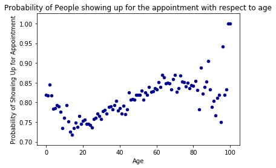

```python
prob_df = calc_probability('age')
prob_df.plot(x='age' , y = 'prob_show_up' , kind='scatter' , color='DarkBlue')
plt.ylabel('Probability of Showing Up for Appointment')
plt.xlabel('Age')
plt.title('Probability of People showing up for the appointment with respect to age');
```

From the above scaterplot we that , most of people have a probability of showing up for appointment between .70 to .9 and people aged almost 100 have a high probability of showing up .

```python
# Method for calculating the probability for categorical data
def calc_prob_category(column):
    rows = []
    for value in no_show[column].unique():
        total = len(no_show[no_show[column] == value])
        show_up_count = len(no_show[(no_show[column] == value) & (no_show['no_show'] == 'No')])
        if total != 0:
            probability = show_up_count / total
        row={column: value, 'Probability': probability}
        rows.append(row)
    return pd.DataFrame(rows)
```

```python
#Method for Drawing the Bar Plot
def draw_barplot(column):
    sns.set_style("whitegrid")
    fig, ax = plt.subplots(figsize=(8,5))
    sns.barplot(data = calc_prob_category(column), x=column, y='Probability',ax=ax )
    plt.title('Probability of Showing Up with respect to '+ column.replace('_' , ' '))
    plt.ylabel('Probality of Showing Up')
    plt.xlabel(column.upper().replace('_' , ' '));
```

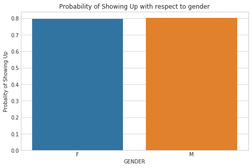

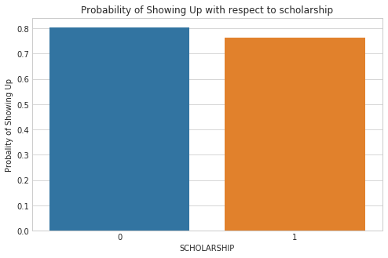

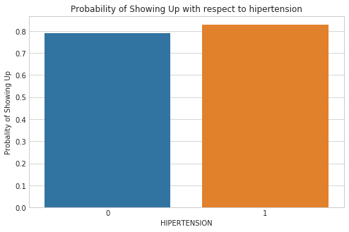

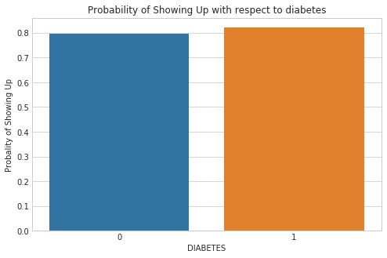

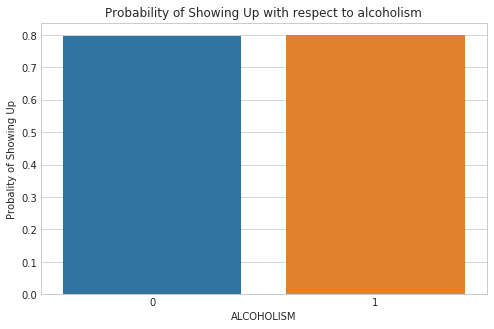

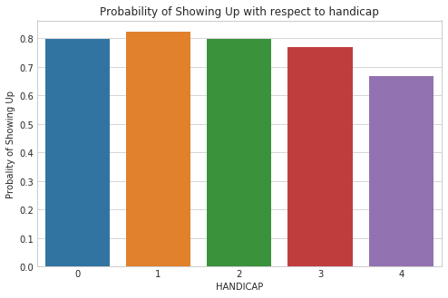

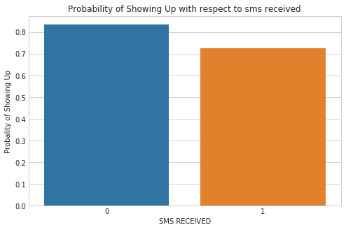

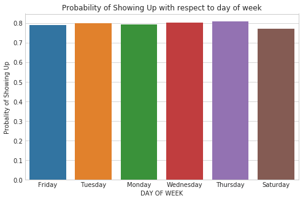

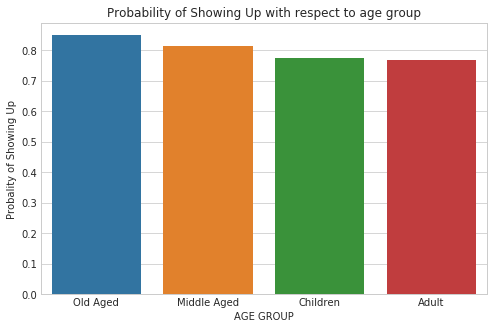

```python
categorical_column_names = ['gender' , 'scholarship' , 'hipertension' , 'diabetes' , 'alcoholism' , 'handicap' , 'sms_received' , 'day_of_week' , 'age_group']
for col in categorical_column_names:
    draw_barplot(col)
```

### Factor : Gender

From the bar plot we see that both Male and Female have almost the same probability of showing up , hence gender does not have a vital affect on showing up for the appointment .

### Factor : Scholarship

From the bar plot we see that people having Scholarship with value 0 has the slightly higher probability of showing up when compared to people having Scholarship with value 1 .

### Factor : Hipertension

From the bar plot we see that people having Hipertension with value 0 has the slightly lesser probability of showing up when compared to people having Hipertension with value 1 .

### Factor : Diabetes

From the bar plot we see that people having Diabetes with value 0 has the slightly lesser probability of showing up when compared to people having Diabetes with value 1 .

### Factor : Alcoholism

From the bar plot we see that people having Alcoholism with value 0 and people having Alcoholism with value 1 have the same probability of showing up . Hence alcoholism does not have a vital affect on showing up for the appointment .

### Factor : Handicap

From the bar plot we see that people having Handicap with value 4 has the least probability of showing up when compared to people having Handicap with other values . So we can say that people with handicap value 4 have the lesser tendency of showing up for the appointment. We see that handicap with value 1 has the highest probability among others.

### Factor : Sms Received

From the bar plot we see that people having sms_received with value 0 has higher probability of showing up when compared to people having sms_received with value 1 . By the visualization we can say Sms Received affects the showing up .

### Factor : Day of Week

From the bar plot we see that almost all the day of week have the probability of showing up nearly to .8 . Hence day of week does not have a vital affect on showing up for the appointment .

### Factor : Age Group

From the bar plot we see that age groups have varied probability of showing up for the appointment .

## Conclusions

After performing the Exploratory Data Analysis , we see that factors such as *Age , Sms received and handicap* has affect on showing up for the scheduled appointment . However further analysis such as inferential statistics has to be performed and gain more insights on the data . We should also note that "Causation does not means Correlation".

# Sources

Link for the Data Set - https://www.kaggle.com/joniarroba/noshowappointments Tutorial for Cross Tab - https://www.youtube.com/watch?v=I_kUj-MfYys https://pandas.pydata.org/pandas-docs/stable/generated/pandas.crosstab.html

Seaborn Tutorial - https://seaborn.pydata.org/tutorial.html

```python
from subprocess import call
call(['python', '-m', 'nbconvert', 'Investigate_a_Dataset.ipynb'])
```

```
0
```